> **Tip**: Welcome to the Investigate a Dataset project! You will find tips in quoted sections like this to help organize your approach to your investigation. Once you complete this project, remove these **Tip** sections from your report before submission. First things first, you might want to double-click this Markdown cell and change the title so that it reflects your dataset and investigation.

# Project: Investigate a Dataset - [noshowappointments]

- Introduction
- Data Wrangling
- Exploratory Data Analysis
- Conclusions

## Introduction

### Dataset Description

> **Tip**: In this section of the report, provide a brief introduction to the dataset you've selected/downloaded for analysis. Read through the description available on the homepage-links present [here](https://docs.google.com/document/d/e/2PACX-1vTlVmknRRnfy_4eTrjw5hYGaiQim5ctr9naaRd4V9du2B5bxpd8FEH3KtDgp8qVekw7Cj1GLk1IXdZi/pub?embedded=True). List all column names in each table, and their significance. In case of multiple tables, describe the relationship between tables.

### Question(s) for Analysis

> **Tip**: Clearly state one or more questions that you plan on exploring over the course of the report. You will address these questions in the **data analysis** and **conclusion** sections. Try to build your report around the analysis of at least one dependent variable and three independent variables. If you're not sure what questions to ask, then make sure you familiarize yourself with the dataset, its variables and the dataset context for ideas of what to explore.

> **Tip**: Once you start coding, use NumPy arrays, Pandas Series, and DataFrames where appropriate rather than Python lists and dictionaries. Also, **use good coding practices**, such as, define and use functions to avoid repetitive code. Use appropriate comments within the code cells, explanation in the mark-down cells, and meaningful variable names.

> Question 1 Gender committed to attending appointment? which gender attended appointments

> Question 2 Age committed to attending appointment? what ages are mostly attending appointments

> Question 3 Are sms related to attending appointment? what is the relationship between sms sent and showing up for appointment

> Question 4 Neibourhoods attending appointment? which neibourhoods are showing up for appointments.

```python
# Use this cell to set up import statements for all of the packages that you
#   plan to use.

import numpy as np
import pandas as pd
import matplotlib.pyplot as plt

# Remember to include a 'magic word' so that your visualizations are plotted
#   inline with the notebook. See this page for more:
#   http://ipython.readthedocs.io/en/stable/interactive/magics.html
```

```python
# Upgrade pandas to use dataframe.explode() function.
!pip install --upgrade pandas==0.25.0
```

[output not shown]

[output not shown]

[output cut: 49 more lines]

[output not shown]

[output not shown]

[output not shown]

[output cut: 201 more lines]

[output not shown]

## Data Wrangling

> **Tip**: In this section of the report, you will load in the data, check for cleanliness, and then trim and clean your dataset for analysis. Make sure that you **document your data cleaning steps in mark-down cells precisely and justify your cleaning decisions.**

### General Properties

> **Tip**: You should *not* perform too many operations in each cell. Create cells freely to explore your data. One option that you can take with this project is to do a lot of explorations in an initial notebook. These don't have to be organized, but make sure you use enough comments to understand the purpose of each code cell. Then, after you're done with your analysis, create a duplicate notebook where you will trim the excess and organize your steps so that you have a flowing, cohesive report.

```python
# Load your data and print out a few lines. Perform operations to inspect data
#   types and look for instances of missing or possibly errant data.

df = pd.read_csv('noshowappointments-kagglev2-may-2016.csv')

df.head()
```

|  | PatientId | AppointmentID | Gender | ScheduledDay | AppointmentDay | Age | Neighbourhood | Scholarship | Hipertension | Diabetes | Alcoholism | Handcap | SMS_received | No-show |
| --- | --- | --- | --- | --- | --- | --- | --- | --- | --- | --- | --- | --- | --- | --- |
| 0 | 2.987250e+13 | 5642903 | F | 2016-04-29T18:38:08Z | 2016-04-29T00:00:00Z | 62 | JARDIM DA PENHA | 0 | 1 | 0 | 0 | 0 | 0 | No |
| 1 | 5.589978e+14 | 5642503 | M | 2016-04-29T16:08:27Z | 2016-04-29T00:00:00Z | 56 | JARDIM DA PENHA | 0 | 0 | 0 | 0 | 0 | 0 | No |
| 2 | 4.262962e+12 | 5642549 | F | 2016-04-29T16:19:04Z | 2016-04-29T00:00:00Z | 62 | MATA DA PRAIA | 0 | 0 | 0 | 0 | 0 | 0 | No |
| 3 | 8.679512e+11 | 5642828 | F | 2016-04-29T17:29:31Z | 2016-04-29T00:00:00Z | 8 | PONTAL DE CAMBURI | 0 | 0 | 0 | 0 | 0 | 0 | No |
| 4 | 8.841186e+12 | 5642494 | F | 2016-04-29T16:07:23Z | 2016-04-29T00:00:00Z | 56 | JARDIM DA PENHA | 0 | 1 | 1 | 0 | 0 | 0 | No |

### Data Cleaning

> **Tip**: Make sure that you keep your reader informed on the steps that you are taking in your investigation. Follow every code cell, or every set of related code cells, with a markdown cell to describe to the reader what was found in the preceding cell(s). Try to make it so that the reader can then understand what they will be seeing in the following cell(s).

```python
# After discussing the structure of the data and any problems that need to be
#   cleaned, perform those cleaning steps in the second part of this section.
#checking the number of rows and any missing values

df.info()
```

```
<class 'pandas.core.frame.DataFrame'>
RangeIndex: 110527 entries, 0 to 110526
Data columns (total 14 columns):
 #   Column          Non-Null Count   Dtype
---  ------          --------------   -----
 0   PatientId       110527 non-null  float64
 1   AppointmentID   110527 non-null  int64
 2   Gender          110527 non-null  object
 3   ScheduledDay    110527 non-null  object
 4   AppointmentDay  110527 non-null  object
 5   Age             110527 non-null  int64
 6   Neighbourhood   110527 non-null  object
 7   Scholarship     110527 non-null  int64
 8   Hipertension    110527 non-null  int64
 9   Diabetes        110527 non-null  int64
 10  Alcoholism      110527 non-null  int64
 11  Handcap         110527 non-null  int64
 12  SMS_received    110527 non-null  int64
 13  No-show         110527 non-null  object
dtypes: float64(1), int64(8), object(5)
memory usage: 11.8+ MB
```

```python
#checking the number of rows and colomns

df.shape
```

```
(110527, 14)
```

```python
# converting some columns that has date to a datetime datatype

df['ScheduledDay'] = pd.to_datetime(df['ScheduledDay'])
df['AppointmentDay'] = pd.to_datetime(df['AppointmentDay'])
```

```python
#check for duplicate

df.duplicated().sum()
```

```
0
```

```python
    df.rename(columns={'No-show':'No_show'}, inplace='true')
```

```python
#on no show data converting the yes to 1 and no to 0 for easy manipulation

df.No_show[df['No_show'] == 'Yes'] = '1'
df.No_show[df['No_show'] == 'No'] = '0'
df['No_show'] = pd.to_numeric(df['No_show'])
```

```python
#creating diffrent colomns for th

showed = df['No_show'] == 0
not_showed = df['No_show'] == 1
df['showed'] = showed
df['not_showed'] = not_showed
```

```python
#checking on both the oldest and youngest person

print('minimum age:',df['Age'].min())

print('maximum age:',df['Age'].max())
```

```
minimum age: -1
maximum age: 115
```

```python
#since no one is -1 years old drop -1 vavue mem

df=  df.drop(df[df["Age"]==-1].index)

df.Age.min()
```

```
0
```

```python
#checking if the -1 year has been dropped

print('minimum age:',df['Age'].min())
```

```
minimum age: 0
```

```python
df[["ScheduledDay","AppointmentDay"]].describe()
```

|  | ScheduledDay | AppointmentDay |
| --- | --- | --- |
| count | 110526 | 110526 |
| unique | 103548 | 27 |
| top | 2016-05-06 07:09:54+00:00 | 2016-06-06 00:00:00+00:00 |
| freq | 24 | 4691 |
| first | 2015-11-10 07:13:56+00:00 | 2016-04-29 00:00:00+00:00 |
| last | 2016-06-08 20:07:23+00:00 | 2016-06-08 00:00:00+00:00 |

```python
#cross checking if all colums are correct

df.head()
```

|  | PatientId | AppointmentID | Gender | ScheduledDay | AppointmentDay | Age | Neighbourhood | Scholarship | Hipertension | Diabetes | Alcoholism | Handcap | SMS_received | No_show | showed | not_showed |
| --- | --- | --- | --- | --- | --- | --- | --- | --- | --- | --- | --- | --- | --- | --- | --- | --- |
| 0 | 2.987250e+13 | 5642903 | F | 2016-04-29 18:38:08+00:00 | 2016-04-29 00:00:00+00:00 | 62 | JARDIM DA PENHA | 0 | 1 | 0 | 0 | 0 | 0 | 0 | True | False |
| 1 | 5.589978e+14 | 5642503 | M | 2016-04-29 16:08:27+00:00 | 2016-04-29 00:00:00+00:00 | 56 | JARDIM DA PENHA | 0 | 0 | 0 | 0 | 0 | 0 | 0 | True | False |
| 2 | 4.262962e+12 | 5642549 | F | 2016-04-29 16:19:04+00:00 | 2016-04-29 00:00:00+00:00 | 62 | MATA DA PRAIA | 0 | 0 | 0 | 0 | 0 | 0 | 0 | True | False |
| 3 | 8.679512e+11 | 5642828 | F | 2016-04-29 17:29:31+00:00 | 2016-04-29 00:00:00+00:00 | 8 | PONTAL DE CAMBURI | 0 | 0 | 0 | 0 | 0 | 0 | 0 | True | False |
| 4 | 8.841186e+12 | 5642494 | F | 2016-04-29 16:07:23+00:00 | 2016-04-29 00:00:00+00:00 | 56 | JARDIM DA PENHA | 0 | 1 | 1 | 0 | 0 | 0 | 0 | True | False |

## Exploratory Data Analysis

> **Tip**: Now that you've trimmed and cleaned your data, you're ready to move on to exploration. **Compute statistics** and **create visualizations** with the goal of addressing the research questions that you posed in the Introduction section. You should compute the relevant statistics throughout the analysis when an inference is made about the data. Note that at least two or more kinds of plots should be created as part of the exploration, and you must compare and show trends in the varied visualizations.

> **Tip**: - Investigate the stated question(s) from multiple angles. It is recommended that you be systematic with your approach. Look at one variable at a time, and then follow it up by looking at relationships between variables. You should explore at least three variables in relation to the primary question. This can be an exploratory relationship between three variables of interest, or looking at how two independent variables relate to a single dependent variable of interest. Lastly, you should perform both single-variable (1d) and multiple-variable (2d) explorations.

### Research Question 1 (Gender committed to attending appointment?)

```python
# Use this, and more code cells, to explore your data. Don't forget to add
#   Markdown cells to document your observations and findings.
#which gender attands more appointments

No_Showt_gender = df.groupby('Gender')['No_show'].value_counts().unstack()
No_Showt_gender
```

| No_show Gender | 0 | 1 |
| --- | --- | --- |
| F | 57245 | 14594 |
| M | 30962 | 7725 |

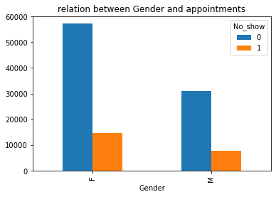

```python
#relationship btw gender and appointment

plot1 =df.groupby('Gender')['No_show'].value_counts().unstack().plot.bar()
plt.title("relation between Gender and appointments")
xlabel=('Gender')
ylabel=('appointments')
```

# Summary

In the above graph we are able to see that more females were able to attend appointmets compared to men. Secomdly also more ladies didnot attend appointmets

### Research Question 2 (Age committed to attending appointment?)

```python
# Continue to explore the data to address your additional research
#   questions. Add more headers as needed if you have more questions to
#   investigate.

def age_group():
    No_Showt_age = df.groupby('Age')['No_show'].value_counts().unstack()

age_group()
```

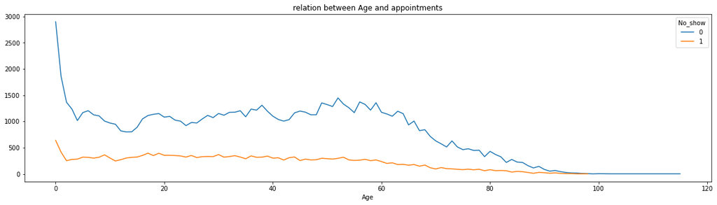

```python
#what is the relaship btw age and showing up of appointments

plot2 =df.groupby('Age')['No_show'].value_counts().unstack().plot(kind='line',figsize=(20,5))

plt.title("relation between Age and appointments")
xlabel=('Age')
plt.ylabel=('appointments')
```

# Summary

[figure not shown]

```python
#use of a pie to display the relationship btw age and showing up for appointments

df.not_showed.value_counts().plot.pie()
plt.title("relation between Age and appointments")
```

### Research Question 3 (Are sms related to attending appointment?)

```python
#relationship btw SMS sent and the rate of showing up of appintments

No_Show_sms = df.groupby('SMS_received')['No_show'].value_counts().unstack()
No_Show_sms
```

| No_show SMS_received | 0 | 1 |
| --- | --- | --- |
| 0 | 62509 | 12535 |
| 1 | 25698 | 9784 |

[output not shown]

[output cut: 3519 more lines]

[output not shown]

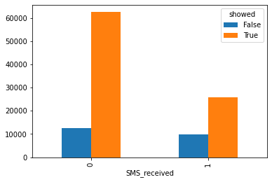

```python
plot3 =df.groupby('SMS_received')['showed'].value_counts().unstack().plot(kind='bar')

#df.SMS_received.plot.hist()
```